# Practical Machine Learning Assignment

Nino Pozar

28th January 2019

### Background

Using devices such as Jawbone Up, Nike FuelBand, and Fitbit it is now possible to collect a large amount of data about personal activity relatively inexpensively. These type of devices are part of the quantified self movement – a group of enthusiasts who take measurements about themselves regularly to improve their health, to find patterns in their behavior, or because they are tech geeks. One thing that people regularly do is quantify how much of a particular activity they do, but they rarely quantify how well they do it. In this project, your goal will be to use data from accelerometers on the belt, forearm, arm, and dumbell of 6 participants. They were asked to perform barbell lifts correctly and incorrectly in 5 different ways. More information is available from http://web.archive.org/web/20161224072740/http:/groupware.les.inf.puc-rio.br/har.Weight.

The goal of this analysis is to develop a machine learning model to predict the manner that participants did the exercise from new set of measurements, as accurately as possible. In this analysis we will describe the steps, models and the thinking that was done to successfully develop machine learning model and the models will be evalueated using cross-validation.

### Setting all up

In this first part, we need to download the training and testing data, and install the packages needed for the analysis.

```r
## Installing required packages
required_packages <- c("dplyr", "ggplot2", "caret", "corrplot", "knitr")
packages_to_install <- required_packages[!(required_packages %in% installed.packages()[,"Package"])]
if(length(packages_to_install)) install.packages(packages_to_install)
lapply(required_packages, require, character.only = TRUE)

## Downloading the data
if(!file.exists("./data")) {
  dir.create("./data")
  url.train <- "https://d396qusza40orc.cloudfront.net/predmachlearn/pml-training.csv"
  url.test <- "https://d396qusza40orc.cloudfront.net/predmachlearn/pml-testing.csv"
  download.file(url.train, "./data/train.csv")
  download.file(url.test, "./data/test.csv")
}

## Reading in the training and test data
training <- read.table("./data/train.csv", sep=",", header=TRUE)
testing <- read.table("./data/test.csv", sep=",", header=TRUE)
```

### Exploratory data analysis

To be able to develop a good machine learning algorithm, we need to explore the data we have. We take a look at the structure od the data and check the dimensions. We also checked if there are any missing values within the data.

```r
kable(head(training))
```

| X | user_name | raw_timestamp_part_1 | raw_timestamp_part_2 | cvtd_timestamp | new_window | num_window | roll_belt | pitch_belt | yaw_belt | total_accel_belt | kurtosis_roll_belt | kurtosis_picth_belt | kurtosis_yaw_belt | skewness_roll_belt | skewness_roll_belt.1 | skewness_yaw_belt | max_roll_belt | max_picth_belt | max_yaw_belt | min_roll_belt | min_pitch_belt | min_yaw_belt | amplitude_roll_belt | amplitude_pitch_belt | amplitude_yaw_belt | var_total_accel_belt | avg_roll_belt | stddev_roll_belt | var_roll_belt | … |
| --- | --- | --- | --- | --- | --- | --- | --- | --- | --- | --- | --- | --- | --- | --- | --- | --- | --- | --- | --- | --- | --- | --- | --- | --- | --- | --- | --- | --- | --- | --- |
| 1 | carlitos | 1323084231 | 788290 | 05/12/2011 11:23 | no | 11 | 1.41 | 8.07 | -94.4 | 3 |  |  |  |  |  |  | NA | NA |  | NA | NA |  | NA | NA |  | NA | NA | NA | NA | … |
| 2 | carlitos | 1323084231 | 808298 | 05/12/2011 11:23 | no | 11 | 1.41 | 8.07 | -94.4 | 3 |  |  |  |  |  |  | NA | NA |  | NA | NA |  | NA | NA |  | NA | NA | NA | NA | … |
| 3 | carlitos | 1323084231 | 820366 | 05/12/2011 11:23 | no | 11 | 1.42 | 8.07 | -94.4 | 3 |  |  |  |  |  |  | NA | NA |  | NA | NA |  | NA | NA |  | NA | NA | NA | NA | … |
| 4 | carlitos | 1323084232 | 120339 | 05/12/2011 11:23 | no | 12 | 1.48 | 8.05 | -94.4 | 3 |  |  |  |  |  |  | NA | NA |  | NA | NA |  | NA | NA |  | NA | NA | NA | NA | … |
| 5 | carlitos | 1323084232 | 196328 | 05/12/2011 11:23 | no | 12 | 1.48 | 8.07 | -94.4 | 3 |  |  |  |  |  |  | NA | NA |  | NA | NA |  | NA | NA |  | NA | NA | NA | NA | … |
| 6 | carlitos | 1323084232 | 304277 | 05/12/2011 11:23 | no | 12 | 1.45 | 8.06 | -94.4 | 3 |  |  |  |  |  |  | NA | NA |  | NA | NA |  | NA | NA |  | NA | NA | NA | NA | … |

```r
str(training)
```

```
'data.frame':   19622 obs. of  160 variables:
 $ X                       : int  1 2 3 4 5 6 7 8 9 10 ...
 $ user_name               : Factor w/ 6 levels "adelmo","carlitos",..: 2 2 2 2 2 2 2 2 2 2 ...
 $ raw_timestamp_part_1    : int  1323084231 1323084231 1323084231 1323084232 1323084232 1323084232 1323084232 1323084232 1323084232 1323084232 ...
 $ raw_timestamp_part_2    : int  788290 808298 820366 120339 196328 304277 368296 440390 484323 484434 ...
 $ cvtd_timestamp          : Factor w/ 20 levels "02/12/2011 13:32",..: 9 9 9 9 9 9 9 9 9 9 ...
 $ new_window              : Factor w/ 2 levels "no","yes": 1 1 1 1 1 1 1 1 1 1 ...
 $ num_window              : int  11 11 11 12 12 12 12 12 12 12 ...
 $ roll_belt               : num  1.41 1.41 1.42 1.48 1.48 1.45 1.42 1.42 1.43 1.45 ...
 $ pitch_belt              : num  8.07 8.07 8.07 8.05 8.07 8.06 8.09 8.13 8.16 8.17 ...
 $ yaw_belt                : num  -94.4 -94.4 -94.4 -94.4 -94.4 -94.4 -94.4 -94.4 -94.4 -94.4 ...
 $ total_accel_belt        : int  3 3 3 3 3 3 3 3 3 3 ...
 $ kurtosis_roll_belt      : Factor w/ 397 levels "","-0.016850",..: 1 1 1 1 1 1 1 1 1 1 ...
 $ kurtosis_picth_belt     : Factor w/ 317 levels "","-0.021887",..: 1 1 1 1 1 1 1 1 1 1 ...
 $ kurtosis_yaw_belt       : Factor w/ 2 levels "","#DIV/0!": 1 1 1 1 1 1 1 1 1 1 ...
```

[output cut: 86 more lines]

```r
dim(training)
```

```
[1] 19622   160
```

```r
dim(testing)
```

```
[1]  20 160
```

```r
message("number of NAs: ", sum(sapply(training,function (x) {sum(is.na(x))})))
```

```
number of NAs: 1287472
```

```r
message("number of NAs: ", sum(sapply(testing,function (x) {sum(is.na(x))})))
```

```
number of NAs: 2000
```

We have seen that in our training data, there are many missing values; NAs. By looking at the head of the data, we can see that NAs appear in specific pattern, i.e. NAs appear only in specific variables. Furthermore, we examined the response variable *classe* to se how manny observations belong to each class.

```r
kable(summary(training$classe))
```

|  | x |
| --- | --- |
| A | 5580 |
| B | 3797 |
| C | 3422 |
| D | 3216 |
| E | 3607 |

### Cleaning the data

As we have mentioned in EDA, there are manny missing values in the data. Because of that, we’ve decided to clean this data by removing the variables that include the aforementioned NA values. Furthermore, we decided to exclude all non-numeric variables from our data and also decided to exclude the first 4 variables that include only information about time and participant.

```r
train <- training [,sapply(training, is.numeric)]
train <- train [, complete.cases(t(train))]
train$classe <- training$classe
train <- train[,-(1:4)]
test <- testing [,sapply(training, is.numeric)]
test <- test [, complete.cases(t(test))]
test$problem_id <- testing$problem_id
test <- test[,-(1:4)]
```

```r
dim(train)
```

```
[1] 19622    53
```

```r
dim(test)
```

```
[1] 20 53
```

```r
message("number of NAs: ", sum(sapply(train,function (x) {sum(is.na(x))})))
```

```
number of NAs: 0
```

```r
message("number of NAs: ", sum(sapply(test,function (x) {sum(is.na(x))})))
```

```
number of NAs: 0
```

### Partitioning the data

Since we have a lot of observations in training set, we’ve decided for a bit unorthodox data partitioning. Also it is worth noting that the second reason for this unorthodox splitting is that our PC cannot handle such large computations. So the split was to take 20% of the data into **train** set used to build the model, and 80% of the data to **vali** set that is used as out-of-sample data for cross-validation of the model and picking the best model. The split on validation set is needed since test set data provided is unsupervised, i.e. response variable is not provided. So the accuracy on validation data represents the accuracy of the model on the data that model has never seen before and thus we can estimate the out-of-samle error, which is unbiased by model development and thus does not overfit the accuracy.

```r
set.seed(1)
inTrain <- createDataPartition(y=train$classe, p=0.2, list=FALSE)
vali <- train [-inTrain,]
train <- train [inTrain,]
```

[figure not shown]

```r
featurePlot(x=train[,-53], y=train[,53], plot = "pairs")
```

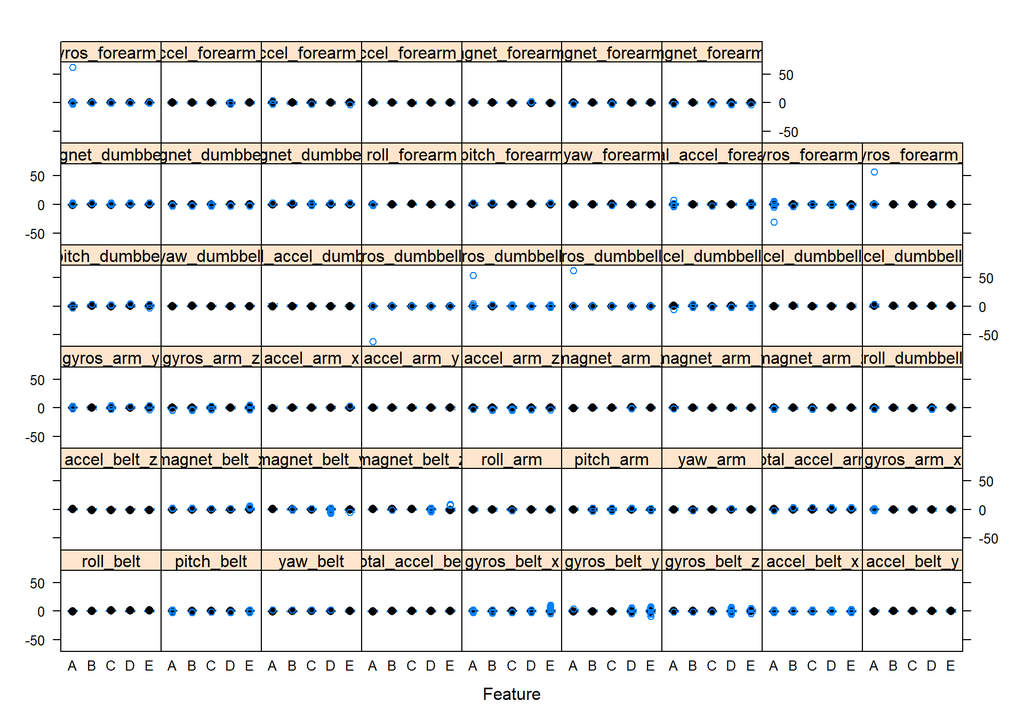

```r
featurePlot(x=scale(train[,-53]), y=train[,53], plot = "box")
```

## Checking for colinearity

The problem in data could be that the predictor variables are highly colinear, or in other words, there are high correlations between the pairs of variables. To inspect this problem, we’ve ploted correlation plot of the data. As we can see on diagonal there are correlations of variable with itself, which are always 1. On the plot we don’t see any real patterns or something that could alarm us, although we cee that come pairs of predictors do have high (positive/negative) correlation. To eliminate this effect we conducted PCA. PCA allowed us to reduce the dimensionality of the data and eliminate some noise (irreducible error) from it. We decided for cutoff of 0.95, which means that we decided to keep all the score vecotrs that explain 95% of the variance in the training data.

Finally, since we conducted PCA, we ploted the first two score vectors against one another and grouped the response variable by color. We’ve done this analysis on training set and we can clearly see that first two principal components cannot seperate the data, and that is the reason why we needed 25 principal components to explain at least 95% of the variance in the training data. We can see some pattern in the data, but more principal components is needed to explain the response (i.e. 25 components).

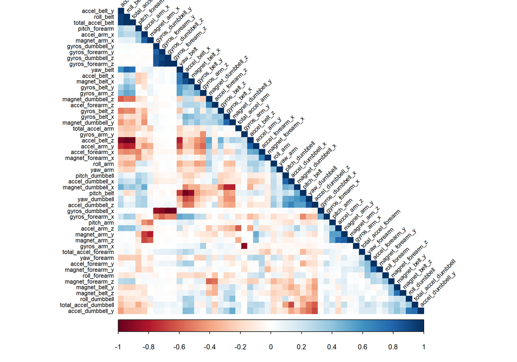

```r
set.seed(1)
corrplot(cor(train[, -53]), method="color", type="lower",
         order="hclust", tl.cex=0.70, tl.col="black", tl.srt = 45)
```

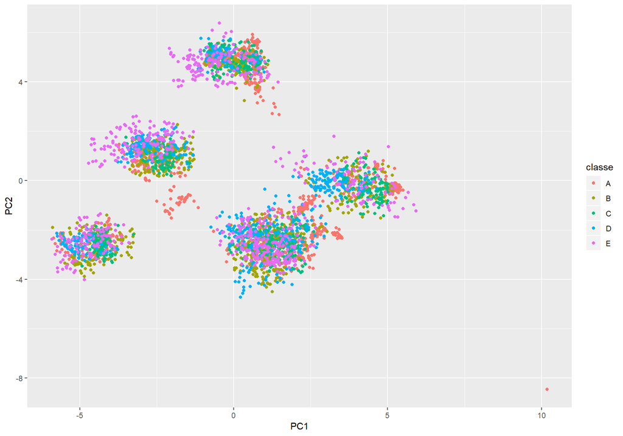

```r
pcaProc <- preProcess(train, method = "pca", thresh = 0.95)
train_pca <- predict(pcaProc, newdata=train)
vali_pca <- predict(pcaProc, newdata=vali)
test_pca <- predict(pcaProc, newdata=test)
ggplot(train_pca, aes(x=PC1, y=PC2, color=classe))+geom_point()
```

After we conducted PCA, we decided to do another data partitioning. Since we will be building models by combining predictors and we have large amount of observations already, we split the training data into two equally sized parts, **train_pca1** and **train_pca2**. This way we will develop single models on **train_pca1** dataset and use the devloped models to combine predictors using the **train_pca2** dataset. This way we won’t use any information from the validation set to develop the final model and we can pick the final model based on the prediction purely from the validation set.

```r
set.seed(1)
inTrain <- createDataPartition(y=train_pca$classe, p=0.5, list=FALSE)
train_pca1 <- train_pca [inTrain,]
train_pca2 <- train_pca [-inTrain,]
```

### Building machine learning models

#### Building simple models

We decided to build 5 machine learning models using caret package in R. The used model were *linear discriminant analysis* (**lda**), *random forests* (**rf**), *k-nearest neighbours* (**knn**), *gradient boosting* (**gbm**) and *neural netowrks* (**nnet**). This way we covered all possible types of machine learning models: linear, tree-based, knn and neural networks. All models are trained in the following sequence of code.

```r
set.seed(1)

model1 <- train(classe~.,  data=train_pca1, method="lda")
model2 <- train(classe~.,  data=train_pca1, method="rf")
model3 <- train(classe~.,  data=train_pca1, method="knn")
model4 <- train(classe~.,  data=train_pca1, method="gbm")
model5 <- train(classe~.,  data=train_pca1, method="nnet")
```

#### Building combined model

Furthermore, we used the predicted responses from the aforedeveloped models to combine them into improved prediction model. We used *random forests* to develop combined model. The model was developed using **train_pca2** training set, as mentioned before, to make sure that we don’t use any information about the valiadtion set in model development.

```r
prediction_df <- function(m1,m2,m3,m4,m5, data) {
  p1 <- predict(m1, data)
  p2 <- predict(m2, data)
  p3 <- predict(m3, data)
  p4 <- predict(m4, data)
  p5 <- predict(m5, data)
  pred_df <- data.frame(p1=p1, p2=p2, p3=p3, p4=p4, p5=p5, classe=data$classe)
  pred_df
}

pred_df <- prediction_df(model1,model2,model3, model4, model5, train_pca2)
model_combined <- train(classe~., data=pred_df, method="rf")
```

### Analyizing the accuracy of the developed models, on in-sample and out-of-sample data via cross-validation

To see how good is our prediction accuracy, we used validation dataset, stored in **vali_pca**. We also showed prediction accuracy on **train_pca1** dataset that was used in model development, and we can clearly see how this accuracy can be missleading and how much higher it is than the validation accuracy (which shows no signs of overfitting). This analysis shows that out of 6 tested models, random forest and combined models show similar and the best accuracy of all models. knn model also showed very satisfying results and gba is also similar. Single hidden layer neural network model and linear model (lda) showed much lower rates of accuracy. All in all this analysis shows us that the best model for predicting classe variable is random forest, which is favorable to the combined models based on speed vs. accuracy trade-off. But since we’ve already developed all models, combined predictors model can also be ok.

```r
accuracy_classe <- function(model,data) {
  a <- confusionMatrix(predict(model,data), data$classe)$overall ["Accuracy"]
  a
}

acc_train1 <- data.frame(
  lda=accuracy_classe(model1,train_pca1),
  rf=accuracy_classe(model2,train_pca1),
  knn=accuracy_classe(model3,train_pca1),
  gbm=accuracy_classe(model4,train_pca1),
  nn=accuracy_classe(model5,train_pca1),
  combo=accuracy_classe(model_combined,prediction_df(model1,model2,model3, model4, model5, train_pca1))
)

acc_train2 <- data.frame(
  lda=accuracy_classe(model1,train_pca2),
  rf=accuracy_classe(model2,train_pca2),
  knn=accuracy_classe(model3,train_pca2),
  gbm=accuracy_classe(model4,train_pca2),
  nn=accuracy_classe(model5,train_pca2),
  combo=accuracy_classe(model_combined,prediction_df(model1,model2,model3, model4, model5, train_pca2))
)

acc_vali <- data.frame(
  lda=accuracy_classe(model1,vali_pca),
  rf=accuracy_classe(model2,vali_pca),
  knn=accuracy_classe(model3,vali_pca),
  gbm=accuracy_classe(model4,vali_pca),
  nn=accuracy_classe(model5,vali_pca),
  combo=accuracy_classe(model_combined,prediction_df(model1,model2,model3, model4, model5, vali_pca))
)

kable(acc_train1)
```

|  | lda | rf | knn | gbm | nn | combo |
| --- | --- | --- | --- | --- | --- | --- |
| Accuracy | 0.540224 | 1 | 0.8635438 | 0.944501 | 0.6680244 | 0.98778 |

```r
kable(acc_vali)
```

|  | lda | rf | knn | gbm | nn | combo |
| --- | --- | --- | --- | --- | --- | --- |
| Accuracy | 0.5206117 | 0.8536477 | 0.7713922 | 0.7636827 | 0.608028 | 0.8514814 |

### Analysis of the best models

In this part we computed the confusion matrix on two best models, as previously mentioned. Those are random forests and combined predictors.

#### Random forests

```r
confusionMatrix(predict(model2,vali_pca), vali_pca$classe)
```

```
Confusion Matrix and Statistics

          Reference
Prediction    A    B    C    D    E
         A 4058  239   97   98   55
         B  166 2522  227   91  189
         C   68  161 2312  245  111
         D  163   56   78 2065   90
         E    9   59   23   73 2440

Overall Statistics

               Accuracy : 0.8536
                 95% CI : (0.848, 0.8591)
    No Information Rate : 0.2844
    P-Value [Acc > NIR] : < 2.2e-16

                  Kappa : 0.8146
 Mcnemar's Test P-Value : < 2.2e-16

Statistics by Class:

                     Class: A Class: B Class: C Class: D Class: E
Sensitivity            0.9091   0.8304   0.8447   0.8029   0.8458
Specificity            0.9565   0.9468   0.9549   0.9705   0.9872
Pos Pred Value         0.8925   0.7894   0.7981   0.8422   0.9370
Neg Pred Value         0.9636   0.9588   0.9668   0.9617   0.9660
Prevalence             0.2844   0.1935   0.1744   0.1639   0.1838
Detection Rate         0.2586   0.1607   0.1473   0.1316   0.1555
Detection Prevalence   0.2897   0.2036   0.1846   0.1562   0.1659
Balanced Accuracy      0.9328   0.8886   0.8998   0.8867   0.9165
```

#### Combined predictors with random forests

```r
confusionMatrix(predict(model_combined,prediction_df(model1,model2,model3, model4, model5, vali_pca)), vali_pca$classe)
```

```
Confusion Matrix and Statistics

          Reference
Prediction    A    B    C    D    E
         A 4021  225   77   95   45
         B  173 2523  226   91  176
         C   78  167 2317  299  104
         D  179   60   68 2032   97
         E   13   62   49   55 2463

Overall Statistics

               Accuracy : 0.851
                 95% CI : (0.8453, 0.8565)
    No Information Rate : 0.2844
    P-Value [Acc > NIR] : < 2.2e-16

                  Kappa : 0.8115
 Mcnemar's Test P-Value : < 2.2e-16

Statistics by Class:

                     Class: A Class: B Class: C Class: D Class: E
Sensitivity            0.9008   0.8308   0.8465   0.7900   0.8537
Specificity            0.9606   0.9474   0.9500   0.9692   0.9860
Pos Pred Value         0.9010   0.7912   0.7815   0.8342   0.9322
Neg Pred Value         0.9606   0.9589   0.9670   0.9593   0.9677
Prevalence             0.2844   0.1935   0.1744   0.1639   0.1838
Detection Rate         0.2562   0.1608   0.1476   0.1295   0.1569
Detection Prevalence   0.2844   0.2032   0.1889   0.1552   0.1683
Balanced Accuracy      0.9307   0.8891   0.8983   0.8796   0.9199
```

### Predicting on test set

Here is given a table of predictions on **test** dataset of every model given in this analysis. We can see how models differ, and we expect, based on our accuracy cross-validation testing, that random forests and combined predictors models give the most accurate prediction of true values for test set. As we can see random forests and combined predictors are predicting the same values for test set. Using the quiz provided, we saw that our model correctly predicts 95% of the test set.

```r
test_pca$classe=test_pca$problem_id
predictions <- data.frame(
  lda=predict(model1, test_pca),
  rf=predict(model2, test_pca),
  knn=predict(model3,test_pca),
  gbm=predict(model4, test_pca),
  nn=predict(model5,test_pca),
  combo=predict(model_combined, prediction_df(model1,model2,model3, model4, model5, test_pca))
)
kable(predictions)
```

| lda | rf | knn | gbm | nn | combo |
| --- | --- | --- | --- | --- | --- |
| D | B | A | B | C | B |
| A | A | A | A | A | A |
| A | C | C | A | C | C |
| A | A | A | A | A | A |
| A | A | A | A | A | A |
| C | E | E | E | E | E |
| D | D | D | D | D | D |
| D | B | B | B | B | B |
| A | A | A | A | A | A |
| A | A | A | A | A | A |
| A | B | B | B | C | B |
| A | C | C | C | C | C |
| B | B | B | B | C | B |
| A | A | A | A | A | A |
| E | E | E | E | E | E |
| B | E | E | E | E | E |
| A | A | A | A | A | A |
| B | B | B | B | B | B |
| A | B | B | B | D | B |
| B | B | B | B | D | B |

### Conclusions

This was very challenging assignment that took few days to solve. By developing 6 machine learning models (lda, rf, knn, gbm, nn and combined predictors), we’ve seen how they clearly perform differently on the same dataset. Using cross-validation we’ve seen how out-of-sample error is much worse than in-sample error. In the end we’ve seen that random forests proved to be the best algorithm for this analysis. The most challenging part of machine learning analysis is cleaning and preparing the data. To achive 100% test set accuracy, we suggest to furthermore improve data preprocessing because it’s not who has the best algorithm that wins, but who has the most data. Thank you very mcuh for reading this.